# Distribuciones Derivadas del Muestreo

Edimer David Jaramillo

22 de mayo de 2018

# Distribución *t* de Student

- Deriva de la distribución normal
- Surge con la dificultad de estimar la media de una población con distribución normal cuando el tamaño de muestra es pequeño.
- Notación: $X \sim t(v)$
- Es de media cero y varianza $\frac{v}{v-2};\ con\ v > 2$
- Simétrica respecto a la media
- La varianza decrece hasta uno cuando el número de grados de libertad aumenta
- [Tabla *t*](https://bioestadistica.github.io/Temas/t.pdf)

La distribución *t* de Student está dada por la siguiente función de densidad:

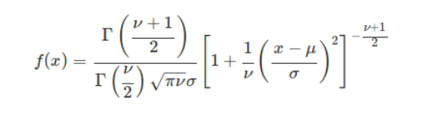

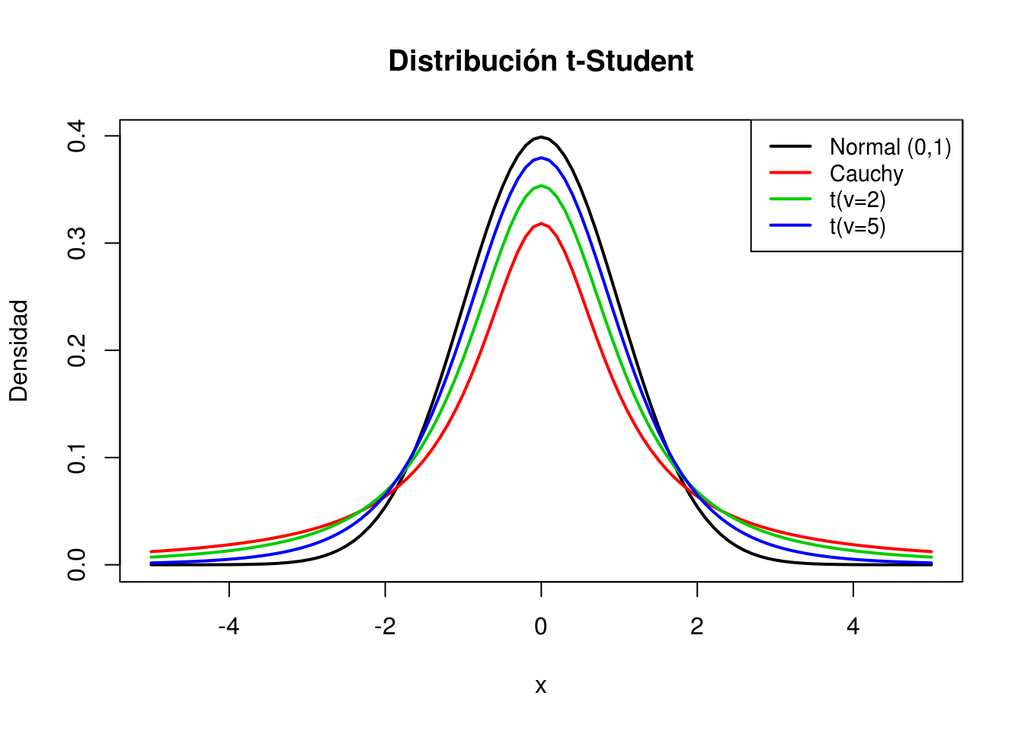

# Distribución F

- Llamada la distribución F de Fisher o F de Snedecor.
- Generalmente es la distribución nula de una prueba estadística (análisis de varianza)
- Notación: $X \sim \chi^2_(d_1,\ d_2)$
- Útil en comparación de varianzas
- [Tabla F](https://bioestadistica.github.io/Temas/F.pdf)

La distribución F surge como resultado de la siguiente operación entre variables aleatorias:
$$F = \frac{Y_1/d_1}{Y_2/d_2}$$

Donde:

- $Y_1$ y $Y_2$ siguen una distribución $\chi^2$ con $k_1$ y $k_2$ grados de libertad, respectivamente.
- $Y_1$ y $Y_2$ son independientes

La distribución F de Fisher está dada por la siguiente función de densidad:

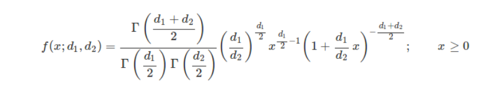

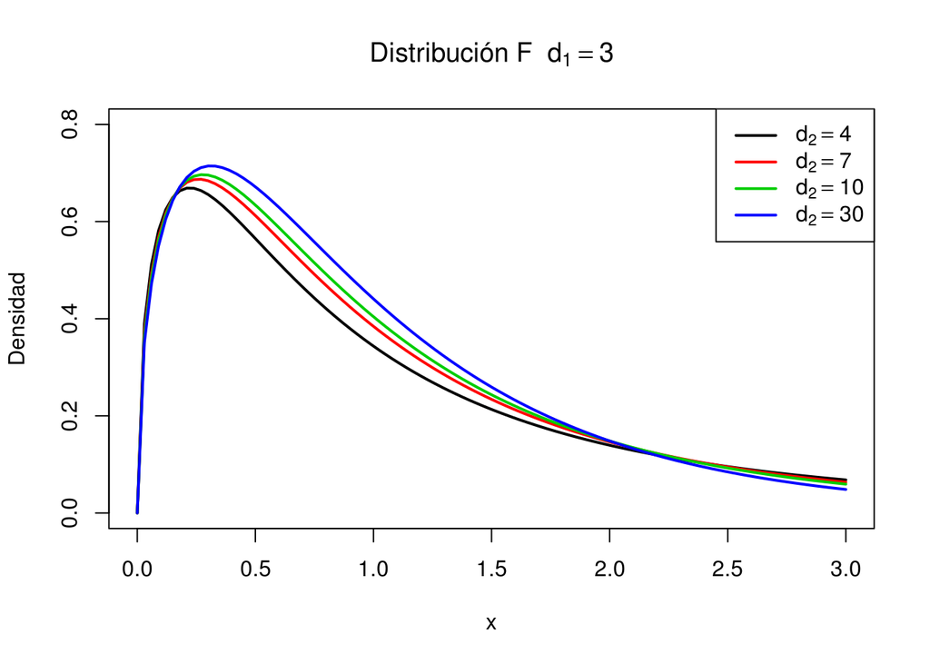

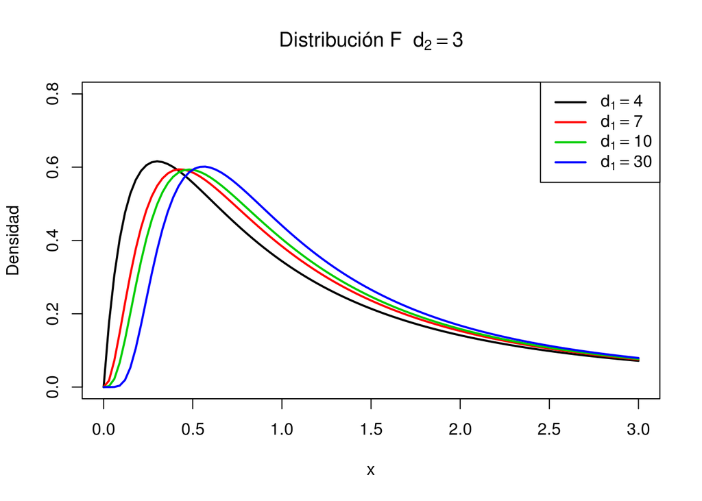

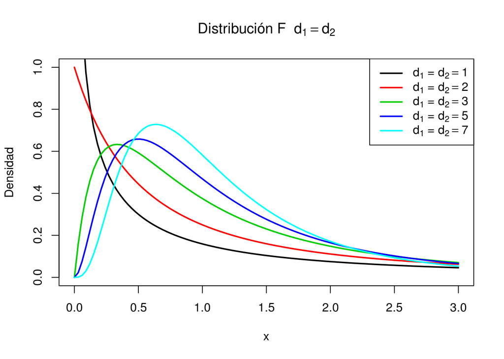

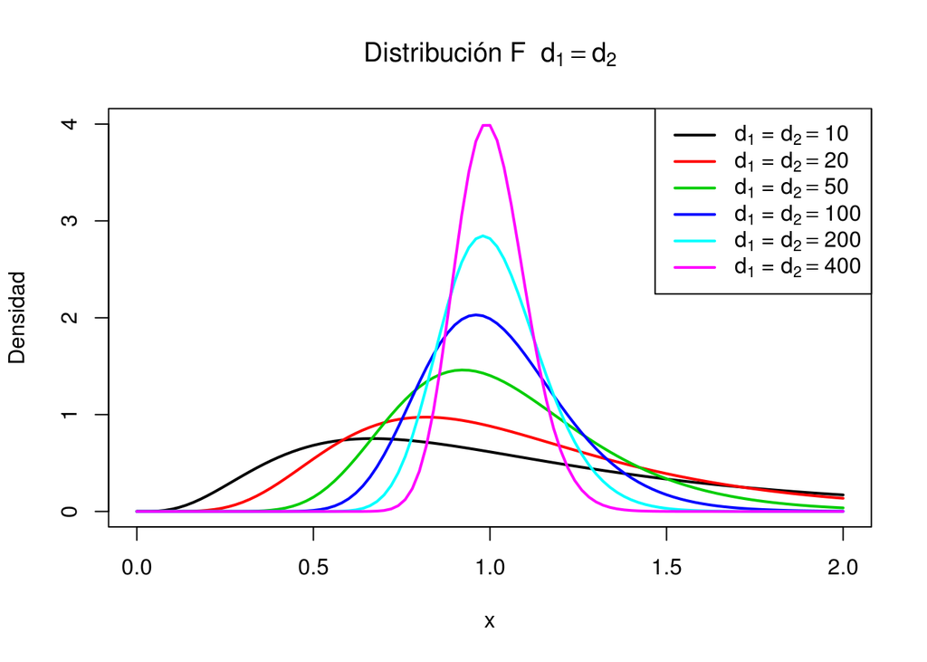

# Distribución de estadísticos muestrales

- El **muestreo** tiene como objetivo inferir propiedades de una población a partir de una fracción de ella, conocida como muestra.
- Desde el punto de vista estadístico lo que se pretende es conocer los parámetros de la distribución de la variable de interés.
- Los estadísticos muestrales sirven como aproximación (estimación) de los parámetros que caracterizan la distribución.
- Los estadísticos son desconocidos, por tanto, se consideran variables aleatorias y como tales, tienen una distribución asociada.

## Conceptos básicos

- **Parámetro:** medida numérica que se obtiene con todos los datos de la población. Los parámetros generalmente son desconocidos.
- **Estadístico:** medida numérica que se obtiene de las muestras con determinado nivel de variación entre muestras.
- **Inferencia estadística:** proceso mediante el cual se generalizan conclusiones a la población, cuyo punto de partida son las muestras. Objetivos de la inferencia estadística:
  - Estimación de parámetros
    - Estimación puntual
    - Intervalos de confianza
  - Pruebas de hipótesis o test de significancia estadística
- Un estadístico muestral, proveniente de una muestra aleatoria, tiene un patrón de comportamiento (predecible) en repetidas muestras, dicho patrón se conoce como la distribución muestral del estadístico.
- Si se conoce la distribución muestral, es posible hacer inferencia estadística.

## Distribución de la media muestral

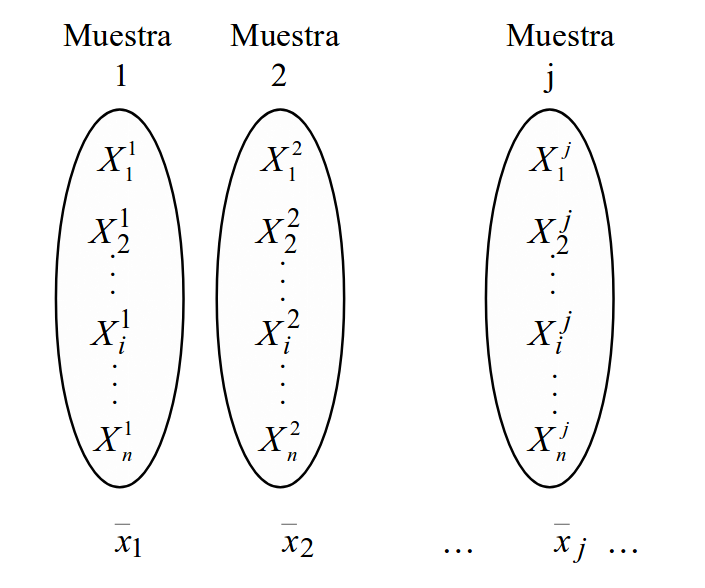

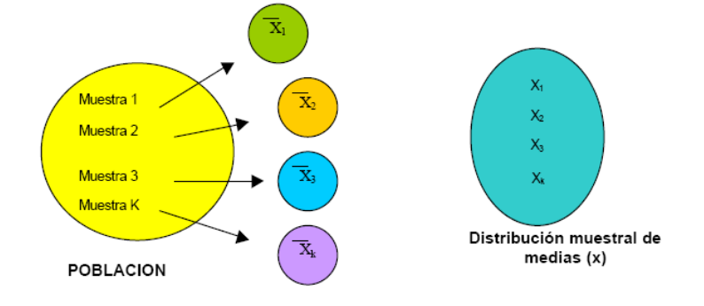

- La variable aleatoria $\bar{X}$ toma valores $\bar{X_1}, \bar{X_2}, ..., \bar{X_j}$
- **Esperanza matemática:** $E[\bar{X}] = \mu_{\bar{X}}$
- **Varianza:** $Var[X] = \frac{\sigma}{\sqrt{n}}$
- **Distribución de probabilidad:** distribución de la media muestral
  $$\bar{X} \sim N(\bar{X}, \frac{\sigma}{\sqrt{n}})$$

Tres casos particulares:

1. Varianza poblacional $\sigma^2$ conocida.
2. Varianza poblacional $\sigma^2$ desconocida.
3. Varianza poblacional $\sigma^2$ desconocida (muestras grandes).

**1. Varianza poblacional $\sigma^2$ conocida:**

- Si $\bar{X}$ se distribuye de forma normal:

$$\bar{X} \sim N(\bar{X}, \frac{\sigma}{\sqrt{n}})$$

- Entonces $Z$:

$$Z = \frac{\bar{X} - \mu}{\sigma/ \sqrt{n}} \sim N(0,1)$$
**2. Varianza poblacional $\sigma^2$ desconocida:**

- El estadístico $T$ definido como:
  $$T = \frac{\bar{X} - \mu}{S/ \sqrt{n}}; donde\ S\ es\ la\ desviación\ muestral$$
- Tiene distribución $t-student$ con $n - 1$ grados de libertad
  $$T = \frac{\bar{X} - \mu}{S/ \sqrt{n}} \sim t_{n-1}$$

**3. Varianza poblacional $\sigma^2$ desconocida en muestras grandes:**

- El estadístico $T$ definido como:
  $$T = \frac{\bar{X} - \mu}{S/ \sqrt{n}}$$
- Tiene distribución Normal Estándar
  $$T = \frac{\bar{X} - \mu}{S/ \sqrt{n}} \sim N(0,1)$$

## Distribución de la diferencia de medias

Dos variables $X$ y $Y$ independientes con distribución normal:
$$X \sim N(\mu_X, \sigma_x)$$
y
$$Y \sim N(\mu_Y, \sigma_y)$$

- El interés radica en conocer si las esperanzas matemáticas de dos variables aleatorias son idénticas o difieren entre si, es decir, $X - Y = \mu_X - \mu_Y$.
- Casos particulares:
  - Varianzas poblacionales conocidas
  - Varianzas poblacionales desconocidas pero iguales
  - Varianzas desconocidas o no, con tamaño $n_x$ y $n_y$ mayores a 30.

**1. Varianzas poblacionales conocidas:**

- La variable aletoria $\bar{X} - \bar{Y}$ con distribución normal

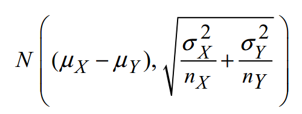

- Entonces Z:

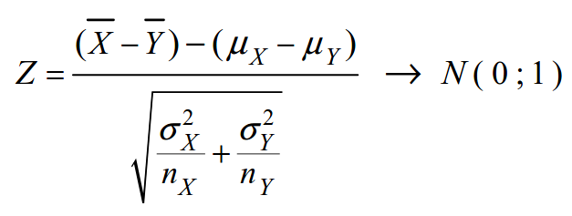

**2. Varianzas poblacionales desconocidas pero iguales:**

- Se tiene que $\sigma^2_X = \sigma^2_Y$
- El estadístico $T$ definido como:

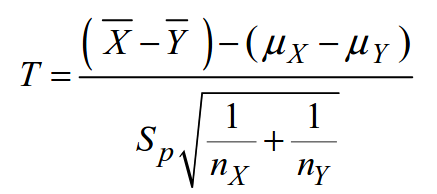

- Donde $S_p^2$:

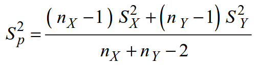

- Tiene distribución $t-student$ con $n_x + n_y-2$ grados de libertad

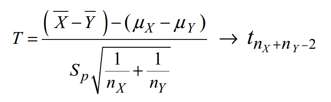

**3. Varianzas desconocidas o no, con tamaño $n_x$ y $n_y$ mayores a 30:**

- El estadístico $Z$ se define como:

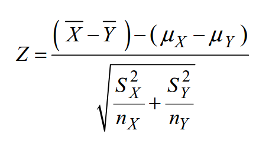

- Con distribución normal:

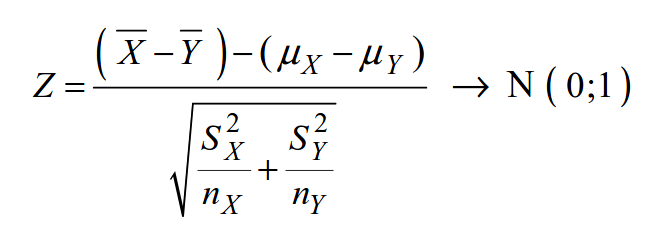

## Distribución de la varianza

- La varianza muestral cambia de muestra en muestra, por tanto, se considera una variable aleatoria y como tal, tiene una distribución asociada.
- Asimétrica, con mayor concentración de valores hacia la izquierda de la media
- Si $S^2$ proviene de una distribución normal, entonces $\frac{S^2(n-1)}{\sigma^2}$ sigue una distribución chi-cuadrado $\chi^2$ con $n-1$ grados de libertad.
- Es posible analizar la distribución del cociente entre varianzas muestrales $\frac{\sigma_x^2}{\sigma_y^2}$

**Distribución del cociente de varianzas muestrales:**

- El estadístico F definido como:

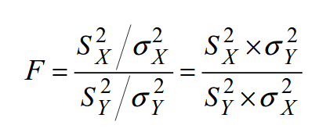

- Tiene distribución $F-Snedecor$ con $n_x -1$ y $n_y - 1$ grados de libertad

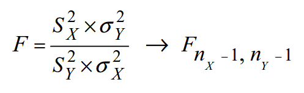

## Distribución de una proporción muestral

- Considere una variable aleatoria $X$ con distribución binomial
  $$X \sim B(n, P)$$
- Para tamaños de muestra grandes, la distribución binomial se aproxima a la normal
  $$X \sim N(np, \sqrt{npq})$$
- Se define el estadístico proporción muestral
  $$\hat{p} = \frac{X}{n}$$
- Verifica
  $$\hat{p} \sim N(p, \sqrt{\frac{pq}{n}})$$
- Por tanto, Z:
  $$Z = \frac{\hat{p}-p}{\sqrt{\frac{pq}{n}}}$$